# 6 - Working with Rasters

In this notebook, we will demonstrate how to use the gplately.Raster class to:

- Create rasters from scattered geographic points
- Download time-dependent rasters
- Plot rasters
- Resize and resample rasters
- Reconstruct rasters back in time
- Query rasters using linear interpolation or a spatial tree search
- Clip rasters by extent

```python
import os, warnings
from pathlib import Path
import cartopy.crs as ccrs
import gplately
import matplotlib.pyplot as plt
import numpy as np
import xarray as xr
from plate_model_manager import PresentDayRasterManager,PlateModelManager
from importlib.resources import files
from gplately.plot import get_age_grid_cmap

data_dir = Path("WorkflowData/06-Raster")
data_dir.mkdir(parents=True, exist_ok=True)
```

```
Matplotlib is building the font cache; this may take a moment.
```

Use [`PlateModelManager`](https://gplates.github.io/plate-model-manager/latest/) to download plate tectonic models, and create [`PlateReconstruction`](https://gplates.github.io/gplately/reconstruction.html#gplately.reconstruction.PlateReconstruction) and [`PlotTopologies`](https://gplates.github.io/gplately/latest/sphinx/html/generated/gplately.PlotTopologies.html) objects.

```python
model_name = "Zahirovic2022"
pmm_model = PlateModelManager().get_model(model_name, data_dir="plate-model-repo")
assert pmm_model is not None, f"Failed to load the {model_name} plate model."
rotation_model = pmm_model.get_rotation_model()
topology_features = pmm_model.get_topologies()
static_polygons = pmm_model.get_static_polygons()

coastlines = pmm_model.get_layer("Coastlines")
continents = pmm_model.get_layer("ContinentalPolygons")
COBs = pmm_model.get_layer("COBs")

model = gplately.PlateReconstruction(rotation_model, topology_features, static_polygons)
gplot = gplately.PlotTopologies(model, coastlines, continents, COBs)
```

Alternatively, you can use the `gplately.auxiliary.get_gplot()` function to get the `PlotTopologies` and `PlateReconstruction` objects.

```
from gplately.auxiliary import get_gplot, get_plate_reconstruction

# use the auxiliary function to create PlotTopologies and PlateReconstruction objects
gplot = get_gplot(model_name) # the PlotTopologies object
model = gplot.plate_reconstruction # the PlateReconstruction object
```

### Create Raster from Scattered Geographic Points

[output not shown]

[output not shown]

[output not shown]

[output not shown]

[output not shown]

[output not shown]

[output not shown]

[output not shown]

[output not shown]

```
Downloaded relief data from fallback URL and saved to WorkflowData/06-Raster/earth_relief_10m.nc
```

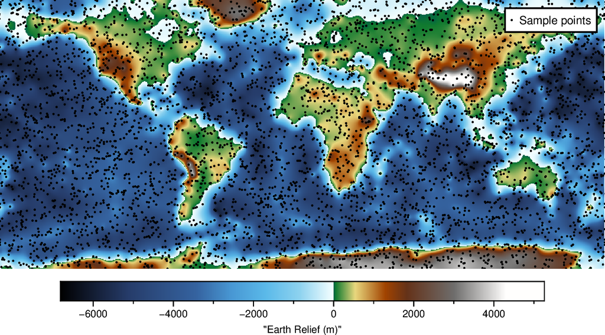

```python
with warnings.catch_warnings():
    warnings.filterwarnings("ignore", category=RuntimeWarning)
    import pygmt
    import urllib.request

    relief_filename = data_dir / "earth_relief_10m.nc"
    fallback_url = "https://repo.gplates.org/webdav/gplately/earth_relief_10m.nc"
    if os.path.isfile(relief_filename):
        relief = xr.open_dataarray(relief_filename)
        print(f"Loaded relief data from {relief_filename}")
    else:
        try:
            relief = pygmt.datasets.load_earth_relief(
                resolution="10m", region=[-180, 180, -80, 80]
            )
            print(f"Downloaded relief data from GMT server and saved to {relief_filename}")
            relief.to_netcdf(relief_filename)
        except Exception as err:
            print(f"GMT server download failed ({err}). Trying fallback URL...")
            urllib.request.urlretrieve(fallback_url, relief_filename)
            relief = xr.open_dataarray(relief_filename)
            print(f"Downloaded relief data from fallback URL and saved to {relief_filename}")

    # Randomly subsample the regular grid into "scattered" points.
    # These points will be used to demonstrate the functionality of the Raster.from_points() method later.
    rng = np.random.default_rng(0)
    ny, nx = relief.shape
    n_points = 5000
    iy = rng.integers(0, ny, n_points)
    ix = rng.integers(0, nx, n_points)

    lon = relief.lon.values[ix]
    lat = relief.lat.values[iy]
    val = relief.values[iy, ix]

    # Create a Raster from the points
    raster = gplately.Raster.from_points(
        lon=lon,
        lat=lat,
        values=val,
        spacing="0.5d",  # dataset covers only a small region, so use fine spacing
    )

    fig = pygmt.Figure()
    raster.plot(ax_or_fig=fig, use_gmt=True)
    fig.plot(
        x=lon,
        y=lat,
        style="c0.05c",
        fill="black",
        label="Sample points",
    )
    fig.colorbar(frame='af+l"Earth Relief (m)"')
    fig.legend()
    fig.show()
```

## Download Time-dependent Rasters

Let's use [`PlateModelManager`](https://gplates.github.io/plate-model-manager/latest/) to download netCDF age grids.

There is a unique age grid for each millionth year - let's access the 0 Ma age grid by passing `time` to the [`get_raster`](https://gplates.github.io/plate-model-manager/latest/plate_model_manager.html#plate_model_manager.PlateModel.get_raster) function.

We can then create a GPlately `Raster` object from the raster file.

```python
time = 0  # Ma
age_grid_raster = gplately.Raster(
    data=pmm_model.get_raster("AgeGrids", time),
    plate_reconstruction=model,
    extent=(-180, 180, -90, 90),
)
test = gplately.Raster(age_grid_raster)
```

## Plot Raster

The `age_grid_raster` is a [`Raster`](https://gplates.github.io/gplately/grids.html#gplately.grids.Raster) object - this object allows us to work with age grids and other rasters. Let's visualise the data with [`imshow`](https://matplotlib.org/stable/api/_as_gen/matplotlib.pyplot.imshow.html).

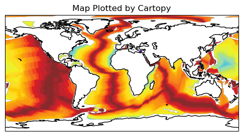

```python
fig = plt.figure(figsize=(6, 6))
ax = fig.add_subplot(111, projection=ccrs.PlateCarree())
ax.coastlines() # type: ignore
age_grid_raster.plot(ax, cmap=get_age_grid_cmap())
ax.set_title("Map Plotted by Cartopy")
plt.show()
```

Use the built-in PyGMT plot engine.

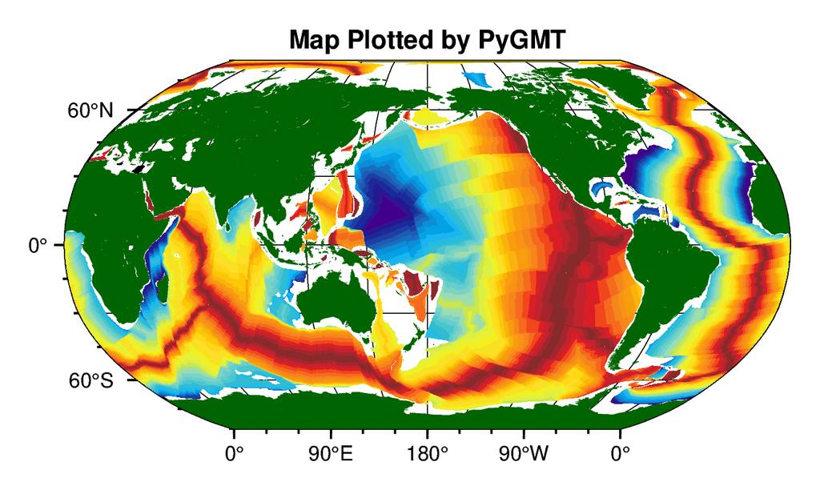

```python
with warnings.catch_warnings():
    warnings.filterwarnings("ignore", category=RuntimeWarning)

    from gplately.auxiliary import get_pygmt_basemap_figure

    fig = get_pygmt_basemap_figure(
        projection="N180/10c",
        region="d",
        frame=["xafg30", "yafg30"],
        title="Map Plotted by PyGMT",
    )
    fig.coast(land="darkgreen")
    age_grid_raster.plot(
        fig, cmap=str(files("gplately").joinpath("data", "agegrid.cpt")), nan_transparent=True, use_gmt=True
    )
    fig.show(crop="+m0.4c")
```

Let's plot this netCDF grid along with coastlines, mid-ocean ridges and subduction zones (with teeth).

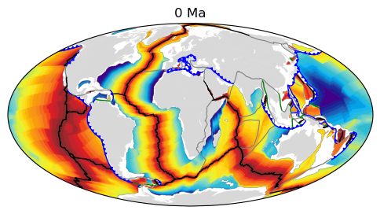

```python
with warnings.catch_warnings():
    warnings.filterwarnings("ignore", category=UserWarning)

    fig = plt.figure(figsize=(6, 6))
    ax = fig.add_subplot(111, projection=ccrs.Mollweide(central_longitude=20))

    gplot.time = time

    age_grid_raster.plot(ax, cmap=get_age_grid_cmap(), vmin=0, vmax=200)
    gplot.plot_coastlines(ax, edgecolor="none", facecolor="grey", alpha=0.3)
    gplot.plot_all_topological_sections(
        ax,
        plot_subduction_teeth=True,
        other_kwargs={"color": "grey", "linewidth": 0.8},
        ridge_kwargs={"color": "black", "linewidth": 1.0},
        transform_kwargs={"color": "green", "linewidth": 1.0},
        trench_kwargs={"color": "blue", "linewidth": 1.0},
    )
    ax.set_title(f"{time} Ma")
    plt.show()
```

## Resize and Resample Raster

Let's resize and resample the present-day age grid.

- [`resize`](https://gplates.github.io/gplately/latest/sphinx/html/generated/gplately.Raster.html#gplately.Raster.resize) - provide the number of points in each direction to resize the raster (e.g. 100 cols by 200 rows)
- [`resample`](https://gplates.github.io/gplately/latest/sphinx/html/generated/gplately.Raster.html#gplately.Raster.resample) - provide the grid spacing in each direction (e.g. 0.1 degrees by 0.2 degrees)

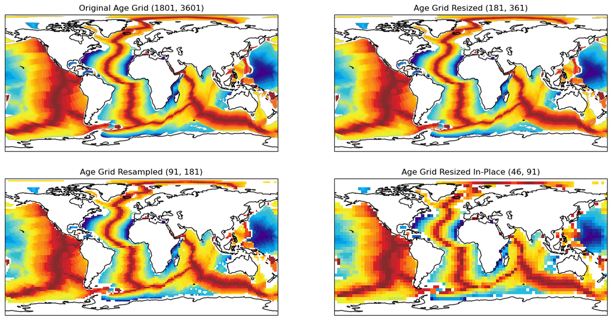

```python
age_grid_raster = gplately.Raster(
    data=pmm_model.get_raster("AgeGrids", time),
    extent=(-180, 180, -90, 90),
)

# Set grid size in x and y directions
age_grid_361_181 = age_grid_raster.resize(361, 181)
age_grid_2_degree_space = age_grid_raster.resample(spacingX=2, spacingY=2)

fig = plt.figure(figsize=(16, 8), dpi=100)

ax_1 = fig.add_subplot(221, projection=ccrs.PlateCarree())
ax_1.coastlines()
age_grid_raster.plot(ax=ax_1, cmap=get_age_grid_cmap(), vmax=200, vmin=0)
ax_1.set_title(f"Original Age Grid {age_grid_raster.shape}")

ax_2 = fig.add_subplot(222, projection=ccrs.PlateCarree())
ax_2.coastlines()
age_grid_361_181.plot(ax=ax_2, cmap=get_age_grid_cmap(), vmax=200, vmin=0)
ax_2.set_title(f"Age Grid Resized {age_grid_361_181.shape}")

ax_3 = fig.add_subplot(223, projection=ccrs.PlateCarree())
ax_3.coastlines()
age_grid_2_degree_space.plot(
    ax=ax_3, cmap=get_age_grid_cmap(), vmax=200, vmin=0
)
ax_3.set_title(f"Age Grid Resampled {age_grid_2_degree_space.shape}")

age_grid_raster.resize(91, 46, inplace=True)

ax_4 = fig.add_subplot(224, projection=ccrs.PlateCarree())
ax_4.coastlines()
age_grid_raster.plot(ax=ax_4, cmap=get_age_grid_cmap(), vmax=200, vmin=0)
ax_4.set_title(f"Age Grid Resized In-Place {age_grid_raster.shape}")

plt.show()
```

## Download ETOPO1

Let's visualise an ETOPO1 relief raster. GPlately also makes it easy to import, using [`PresentDayRasterManager().get_raster`](https://gplates.github.io/plate-model-manager/latest/plate_model_manager.html#plate_model_manager.PresentDayRasterManager.get_raster)

Alternatively, you can import a local netcdf file using by passing the filename to [`gplately.Raster`](https://gplates.github.io/gplately/grids.html#gplately.grids.Raster) or [`gplately.grids.read_netcdf_grid`](https://gplates.github.io/gplately/grids.html#gplately.grids.read_netcdf_grid)

```python
with warnings.catch_warnings():
    warnings.filterwarnings("ignore")

    from matplotlib import image

    etopo = gplately.Raster(
        data=image.imread(PresentDayRasterManager().get_raster("ETOPO1_tif")),
        origin="upper",
    )

    print(np.shape(etopo))
```

```
(2700, 5400, 3)
```

`etopo` is a large (5400 x 2700 pixels) RGB image, with a total of 14,580,000 grid points. We can visualise it using a number of methods, such as [`Raster.plot`](https://gplates.github.io/gplately/grids.html#gplately.grids.Raster.plot).

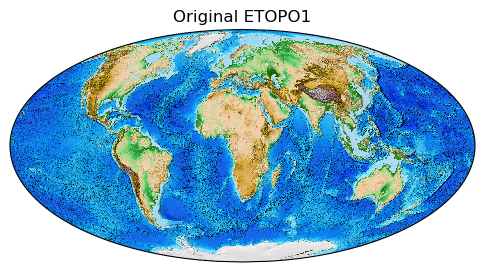

```python
fig = plt.figure(figsize=(6, 6))
ax1 = fig.add_subplot(111, projection=ccrs.Mollweide(central_longitude=20))
etopo.plot(ax=ax1, interpolation="none")
ax1.set_title(f"Original ETOPO1")
plt.show()
```

We can also resize this RGB raster using the [`Raster.resize`](https://gplates.github.io/gplately/grids.html#gplately.grids.Raster.resize) and [`Raster.resample`](https://gplates.github.io/gplately/grids.html#gplately.grids.Raster.resample) methods. Here we resample it to a 0.5 by 0.5 degree resolution, then plot it using [`Raster.plot`](https://gplates.github.io/gplately/grids.html#gplately.grids.Raster.plot).

```
(361, 721, 3)
uint8
```

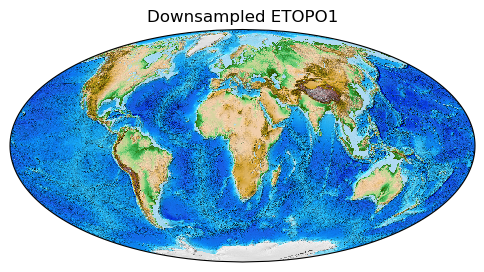

```python
etopo_downscaled = etopo.resample(0.5, 0.5)
print(etopo_downscaled.shape)
print(etopo_downscaled.dtype)

fig = plt.figure(figsize=(6, 6))
ax1 = fig.add_subplot(111, projection=ccrs.Mollweide(central_longitude=20))
ax1.set_title(f"Downsampled ETOPO1")
etopo_downscaled.plot(ax1, interpolation="none")
```

## Reconstruct Raster

The ETOPO1 raster can be reconstructed back in time by assigning a `plate_reconstruction` to the object. We use the plate reconstruction we defined earlier (`model`). Note that a `Raster` object will also accept a `plate_reconstruction` at initialisation.

After this, we use [`reconstruct`](https://gplates.github.io/gplately/grids.html#gplately.grids.Raster.reconstruct) to reconstruct the raster to a given time.

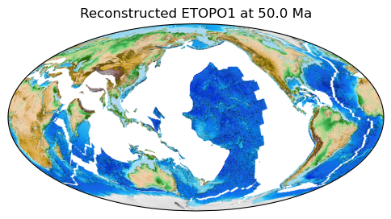

```python
# use the downsampled ETOPO1 so that the reconstruction won't take too long for this demonstration
# assign a plate reconstruction in order to reconstruct the raster
etopo_downscaled.plate_reconstruction = model

white_rgb = (255, 255, 255)  # RGB code for white, to fill gaps in output
etopo_reconstructed = etopo_downscaled.reconstruct(50, threads=4, fill_value=white_rgb)

fig = plt.figure(figsize=(6, 6))
ax1 = fig.add_subplot(111, projection=ccrs.Mollweide(central_longitude=180))
ax1.set_title(f"Reconstructed ETOPO1 at {etopo_reconstructed.time} Ma")
etopo_reconstructed.plot(ax1)
```

`Raster` can be reconstructed in-place (`inplace=True`), and `fill_value` can be set to any valid matplotlib colour when reconstructing RGB images.

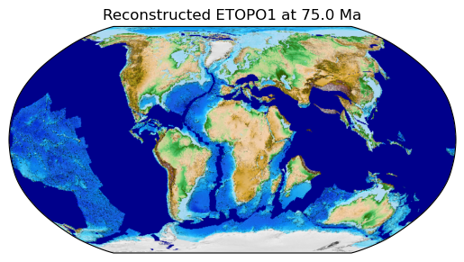

```python
# create a duplicate of the obj
etopo_dup = etopo_downscaled.copy()
etopo_dup.reconstruct(time=75, threads=4, fill_value="darkblue", inplace=True)
etopo_dup.plot(projection=ccrs.Robinson())
plt.gca().set_title(f"Reconstructed ETOPO1 at {etopo_dup.time} Ma")
```

By default, [`Raster.reconstruct`](https://gplates.github.io/gplately/grids.html#gplately.grids.Raster.reconstruct) uses `self.plate_reconstruction.static_polygons` to assign plate IDs to grid points. To override this behaviour, pass any collection of `pygplates.Feature` (e.g. `list`, `pygplates.FeatureCollection`, etc) to the `partitioning_features` argument.

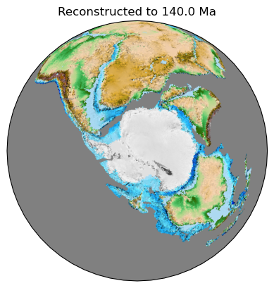

```python
etopo_reconstructed = etopo_downscaled.reconstruct(
    140, partitioning_features=continents, threads=4, fill_value="grey"
)
etopo_reconstructed.plot(projection=ccrs.Orthographic(0, -80))
plt.gca().set_title(f"Reconstructed to {etopo_reconstructed.time} Ma")
```

## Reverse Reconstructions

Rasters can also be reverse reconstructed forward in time! Some data will be lost during the reconstruction because that data doesn't exist at 50 Ma.

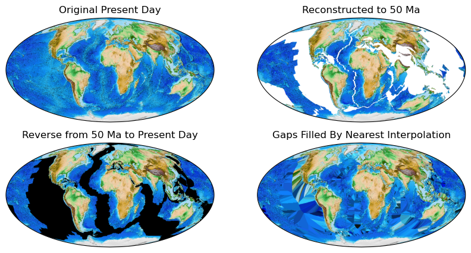

```python
assert etopo_downscaled.shape[2] == 3, "Must be a RGB image"

etopo_50_ma = etopo_downscaled.reconstruct(50, fill_value="white", threads=4)
etopo_reversed_0_ma = etopo_50_ma.reconstruct(0, fill_value=(0, 0, 0), threads=4)

fig, axs = plt.subplots(
    2,
    2,
    figsize=(10, 5),
    subplot_kw={"projection": ccrs.Mollweide(central_longitude=0)},
)
etopo_downscaled.plot(ax=axs[0][0])
etopo_50_ma.plot(ax=axs[0][1])
etopo_reversed_0_ma.plot(ax=axs[1][0])

use_spatial_tree = True  # set this to False to use Linear Interpolation to fill the gaps. (much slower!!)
if use_spatial_tree:
    etopo_reversed_0_ma.fill_gaps(invalid_value=(0, 0, 0), use_spatial_tree=True).plot(
        ax=axs[1][1]
    )
else:
    etopo_reversed_0_ma.fill_gaps(invalid_value=(0, 0, 0), method="linear").plot(
        ax=axs[1][1]
    )

axs[0][0].set_title("Original Present Day")
axs[0][1].set_title("Reconstructed to 50 Ma")
axs[1][0].set_title("Reverse from 50 Ma to Present Day")
if use_spatial_tree:
    axs[1][1].set_title("Gaps Filled By Nearest Interpolation")
else:
    axs[1][1].set_title("Gaps Filled By Linear Interpolation")
plt.show()
```

## Reconstructing NetCDF Raster

Similar to above, we can also reconstruct numeric netcdf grids! GPlately also includes ETOPO1 as a netcdf for download.

```
(361, 721)
```

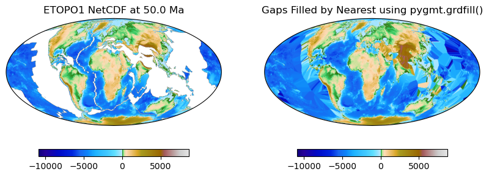

```python
# download ETOPO1 netCDF
etopo_nc = gplately.Raster(data=PresentDayRasterManager().get_raster("ETOPO1_grd"))
etopo_nc._data = etopo_nc._data.astype(float)

# resample to a more manageable size
etopo_nc.resample(0.5, 0.5, inplace=True)
print(etopo_nc.shape)

# Assign plate reconstruction
etopo_nc.plate_reconstruction = model

# Reconstruct raster to 50 Ma
etopo_nc_reconstructed = etopo_nc.reconstruct(50, threads=4)

# plot
fig = plt.figure(figsize=(10, 10))
ax_1 = fig.add_subplot(121, projection=ccrs.Mollweide(central_longitude=20))
im = etopo_nc_reconstructed.plot(
    ax_1, cmap=gplately.get_topo_cmap(), vmin=-10927, vmax=8726
)
fig.colorbar(im, ax=ax_1, pad=0.05, shrink=0.7, orientation="horizontal")
ax_1.set_title(f"ETOPO1 NetCDF at {etopo_nc_reconstructed.time} Ma")

ax_2 = fig.add_subplot(122, projection=ccrs.Mollweide(central_longitude=20))
im = etopo_nc_reconstructed.fill_gaps(use_gmt=True).plot(
    ax_2, cmap=gplately.get_topo_cmap(), vmin=-10927, vmax=8726
)
fig.colorbar(im, ax=ax_2, pad=0.05, shrink=0.7, orientation="horizontal")
ax_2.set_title(f"Gaps Filled by Nearest using pygmt.grdfill()")

plt.show()
```

```python
# Save the reconstructed ETOPO grid to a netCDF file
etopo_nc_reconstructed.save_to_netcdf4(
    data_dir / f"reconstructed_etopo_{etopo_nc_reconstructed.time}.nc",
)
```

## Raster Query by Linear Interpolation

The code cell below demonstrates how to use Raster.query() with linear interpolation to query data from a raster.

[figure not shown]

```python
fig = plt.figure(figsize=(12, 3), dpi=100)

ax_1 = fig.add_subplot(131, projection=ccrs.PlateCarree(central_longitude=0))
etopo_downscaled.plot(ax=ax_1)

extent = (-100, 100, -50, 50)
ax_2 = fig.add_subplot(132, projection=ccrs.PlateCarree(central_longitude=0))
xx, yy = np.meshgrid(
    np.linspace(extent[0], extent[1], 100), np.linspace(extent[2], extent[3], 50)
)
shape = xx.shape
xx = xx.flatten()
yy = yy.flatten()
values = etopo_downscaled.query(lons=xx, lats=yy, interpolation_method="linear")
ax_2.set_extent(extent, crs=ccrs.PlateCarree())
ax_2.set_facecolor("white")
ax_2.scatter(
    xx,
    yy,
    c=values / 255.0,
    marker="o",
    s=3.5,
    transform=ccrs.PlateCarree(),
)

ax_3 = fig.add_subplot(133, projection=ccrs.PlateCarree(central_longitude=0))
ax_3.set_global()
ax_3.imshow(
    np.flipud(np.reshape(values, (shape[0], shape[1], 3))),
    transform=ccrs.PlateCarree(),
    extent=extent,
)

ax_1.set_title(f"Original Image")
ax_2.set_title(f"Values Plotted by scatter()")
ax_3.set_title(f"Values Plotted by imshow()")
fig.suptitle("Raster Query by Linear Interpolation")
fig.tight_layout()
plt.show()
```

This example demonstrates how to query nearest values from a Raster. We'll find which subduction zones form continental arcs by using a continental mask raster, and querying that raster with points projected 250 km from the trench (in the direction of the subducting plate) to determine if they are inside a continent.

```python
# get the continental mask raster
continental_mask_file = os.path.join("NotebookFiles", "continental_grid_0.nc")
if not os.path.isfile(continental_mask_file):
    import urllib.request

    urllib.request.urlretrieve(
        "https://github.com/GPlates/gplately/raw/refs/heads/master/Notebooks/NotebookFiles/continental_grid_0.nc",
        continental_mask_file,
    )

continental_raster = gplately.Raster(continental_mask_file, model)

# tessellate trenches and extract the subduction polarity angle and the lat-lon coordinates
trench_data = model.tessellate_subduction_zones(time)
trench_normal_azimuthal_angle = trench_data[:, 7]
trench_pt_lon = trench_data[:, 0]
trench_pt_lat = trench_data[:, 1]

# calculate 250 km arc distance
arc_distance = 250 / (gplately.tools.geocentric_radius(trench_pt_lat) / 1e3)

# Lat and lon coordinates of all trench points after being projected out 250 km in the direction of subduction.
dlon = arc_distance * np.sin(np.radians(trench_normal_azimuthal_angle))
dlat = arc_distance * np.cos(np.radians(trench_normal_azimuthal_angle))
ilon = trench_pt_lon + np.degrees(dlon)
ilat = trench_pt_lat + np.degrees(dlat)
```

Now use these projected trench points to query the nearest cells in the continental raster using [`Raster.query`](https://gplates.github.io/gplately/grids.html#gplately.Raster.query).

```python
# Query the raster with the projected trench points
sampled_points = continental_raster.query(
    lons=ilon, lats=ilat, interpolation_method="nearest"
)

# The cells of land in the continental raster are 1. Now find all the inland points.
in_raster_indices = sampled_points > 0

# Get the lat-lon coordinates of the in_raster points
lat_in = ilat[in_raster_indices]
lon_in = ilon[in_raster_indices]
```

Plot the inland points along with the raster, trenches, and coastlines.

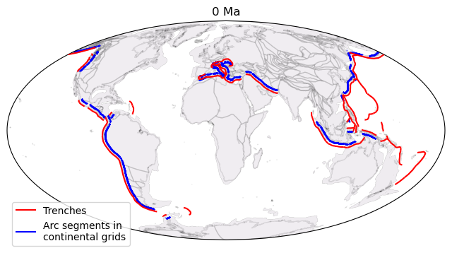

```python
fig = plt.figure(figsize=(8, 6), dpi=100)
ax1 = fig.add_subplot(111, projection=ccrs.Mollweide(central_longitude=20))
gplot.time = time
gplot.plot_grid_from_netCDF(
    ax1, continental_mask_file, cmap="twilight", alpha=0.5, vmin=0, vmax=200
)
gplot.plot_coastlines(ax1, edgecolor="k", facecolor="1", alpha=0.1)
gplot.plot_trenches(ax1, color="r", zorder=5)  # Plot the original trench points in Red

# Plot the projected inland points in Blue
ax1.plot(
    lon_in,
    lat_in,
    linestyle="none",
    marker="o",
    markersize=0.25,
    markerfacecolor="blue",
    markeredgecolor="blue",
    transform=ccrs.PlateCarree(),
)
plt.title(f"{time} Ma")

# Custom legend
from matplotlib.lines import Line2D

handles = [
    Line2D([0], [0], color="red"),
    Line2D([0], [0], color="blue"),
]
labels = [
    "Trenches",
    "Arc segments in \ncontinental grids",
]

plt.legend(handles, labels, loc="lower left", bbox_to_anchor=(0.0, -0.05))
plt.show()
```

### Query Raster by Spatial Tree

We will reuse the inland sample points from previous code cells to demonstrate how to query a raster within a region of interest. This is slower than interpolation. However, this is useful if you need to find the nearest **valid** data points within a region of interest.

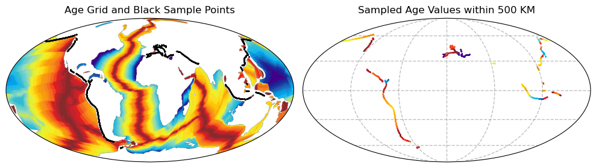

```python
age_grid_raster = gplately.Raster(data=pmm_model.get_raster("AgeGrids", 0))

# plot the age grid raster and black sample points
fig = plt.figure(figsize=(10, 10), dpi=100)
ax_1 = fig.add_subplot(121, projection=ccrs.Mollweide(central_longitude=0))
age_grid_raster.plot(ax=ax_1, cmap=get_age_grid_cmap(), vmax=200, vmin=0)
ax_1.plot(
    lon_in,
    lat_in,
    linestyle="none",
    marker="o",
    markersize=0.25,
    markerfacecolor="black",
    markeredgecolor="black",
    transform=ccrs.PlateCarree(),
)
ax_1.set_title("Age Grid and Black Sample Points")

# plot the data being retrieved by raster query
ax_2 = fig.add_subplot(122, projection=ccrs.Mollweide(central_longitude=0))
ax_2.set_global()
xx = lon_in
yy = lat_in

# You may set the `region_of_interest` to a smaller value, such as 100, to see what will happen.
# You will see fewer points being plotted because there are no valid data within 100 km for some sample points.
roi = 500  # km
values = age_grid_raster.query(lons=xx, lats=yy, region_of_interest=roi)

ax_2.scatter(
    xx,
    yy,
    c=values,
    marker="o",
    s=0.25,
    transform=ccrs.PlateCarree(),
    cmap=get_age_grid_cmap(),
    vmax=200,
    vmin=0,
)

gl = ax_2.gridlines(
    crs=ccrs.PlateCarree(),
    draw_labels=False,
    linewidth=1,
    color="gray",
    alpha=0.5,
    linestyle="--",
)
ax_2.set_title(f"Sampled Age Values within {roi} KM")
fig.tight_layout()
plt.show()
```

### Clip Raster

```
2026-09-14 01:37:31 - gplately - WARNING - The new data shape (66, 87, 3) is different from the old shape (361, 721, 3)
```

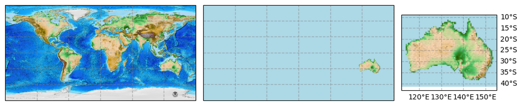

```python
from gplately.utils.feature_filter import (
    FeatureNameFilter,
    PolygonAreaFilter,
    filter_feature_collection,
)

# find the polygon feature with area greater than 7 million and named "Australia",
# which is the mainland of Australia, and use the Australia mainland polygon to clip a raster.
features = filter_feature_collection(
    gplately.load_feature_collection(pmm_model.get_coastlines()),  # type: ignore
    [
        FeatureNameFilter(
            ["Australia"],
            exact_match=True,
            case_sensitive=True,
        ),
        PolygonAreaFilter(7e6, reverse=False),
    ],
)
assert (
    len(features) == 1
), f"Expected to find exactly one feature for the mainland of Australia, but found {len(features)} features."

australia_mainland_geometry = features[0].get_geometry()
# now the austrlia is in a global map
raster_australia = etopo_downscaled.clip_by_polygons(
    [australia_mainland_geometry], fill_value="lightblue"
)

lat_lon = australia_mainland_geometry.to_lat_lon_array()
min_lat = np.min(lat_lon[:, 0])
max_lat = np.max(lat_lon[:, 0])
min_lon = np.min(lat_lon[:, 1])
max_lon = np.max(lat_lon[:, 1])
australia_extent = (
    int(np.floor(min_lon)) - 1,
    int(np.ceil(max_lon)) + 1,
    int(np.floor(min_lat)) - 1,
    int(np.ceil(max_lat)) + 1,
)

clipped_australia = raster_australia.clip_by_extent(australia_extent)

fig, axs = plt.subplots(
    1,
    3,
    figsize=(10, 8),
    gridspec_kw={"width_ratios": [2, 2, 1]},
    subplot_kw={"projection": ccrs.PlateCarree()},
)
fig.tight_layout()
ax_1 = axs[0]
ax_2 = axs[1]
ax_3 = axs[2]

# plot the original raster
ax_1.set_global()
etopo_downscaled.plot(ax=ax_1)
gl = ax_1.gridlines(
    draw_labels=False,
    linewidth=1,
    color="gray",
    alpha=0.5,
    linestyle="--",
)
gl.right_labels = False
gl.top_labels = False

# plot the clipped raster
ax_2.set_global()
raster_australia.plot(ax=ax_2)
gl = ax_2.gridlines(
    draw_labels=False,
    linewidth=1,
    color="gray",
    alpha=0.5,
    linestyle="--",
)

# plot the clipped raster with tighter extent
ax_3.set_extent(australia_extent)
clipped_australia.plot(ax=ax_3)
gl = ax_3.gridlines(
    draw_labels=False,
    linewidth=1,
    color="gray",
    alpha=0.5,
    linestyle="--",
)
gl.right_labels = True
gl.bottom_labels = True

plt.show()
```